# Lab for GEOG 3023: Statistics for Geography

Lab 4: Statistical Relationships in R

Elliot Whitehead

Complete all **5 Questions**, and submit the finished Rmd and knitted HTML file onto Canvas. Don’t forget to change name field in the beginning to your first and last name.

This lab is based on a lab developed by Dr. Matthew Crump at CUNY Brooklyn (https://crumplab.github.io/statisticsLab/)

# Introduction

In lecture, we have been discussing the idea of correlation. This is the idea that two things that we measure can be somehow related to one another. For example, your personal happiness, which we could try to measure say with a questionnaire, might be related to other things in your life that we could also measure, such as number of close friends, yearly salary, how much chocolate you have in your bedroom, or how many times you have said the word Nintendo in your life. Some of the relationships that we can measure are meaningful, and might reflect a causal relationship where one thing causes a change in another thing. Some of the relationships are spurious, and do not reflect a causal relationship.

In this lab you will learn how to compute correlations between two variables in ‘R’, and then ask some questions about the correlations that you observe.

## Learning Goals

1. Compute Pearson’s r between two variables with R
2. Simple linear regression with R
3. Discuss the possible meaning of correlations that you observe

## Getting started

### Load packages

In this lab we will continue use the ‘dplyr’ package used for the last week.

Let’s load the packages:

```r
library(dplyr)
library(ggplot2)
```

### Data

Let’s load the data:

```r
# Make sure the data are in the right folder
#
whr_data <- read.csv('./WHR2021.csv')


# Now browse the data and see what columns the data have. The names of the column should explain themselves
names(whr_data)

# Show the first few rows of the data frame.
head(whr_data)
```

[output not shown]

You should be able to see that there is data for many different countries, across a few different years. There are lots of different kinds of measures, and each are given a name that should explain themselves. You can find out more info here: https://worldhappiness.report/faq/

# Getting Familiar with the Data

## Life Satisfaction over time

One of the most interesting columns is the `Life.Ladder'' variable. This is a descriptor of life satisfaction and happiness. From the WHR website:`This is called the Cantril ladder: it asks respondents to think of a ladder, with the best possible life for them being a 10, and the worst possible life being a 0. They are then asked to rate their own current lives on that 0 to 10 scale.’’ Then WHR calculates the mean rating for each country and that’s the value you see in ``Life.Ladder’’

To start, let’s explore the changes of the Life.Ladder over the years for the United States.

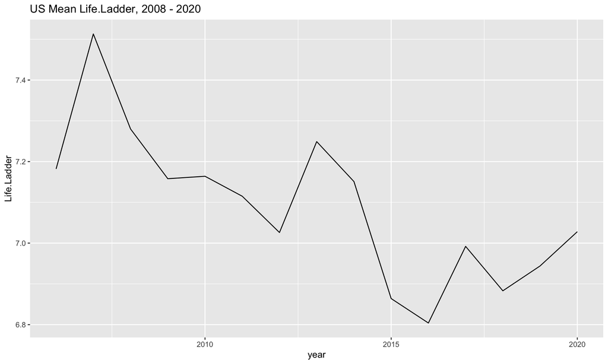

```r
# By using dplyr, we can easily select the rows and columns in the dataframe that we want
# Then save it to a new dataframe called "whr_data_us"
whr_data_us <- whr_data %>%
  select(country, year, Life.Ladder) %>% #select the interested columns
  filter(country == 'United States')  # only choose United States

# Plot
ggplot(whr_data_us, cex=2) + aes(x=year, y=Life.Ladder) + geom_line() +
  ggtitle("US Mean Life.Ladder, 2008 - 2020")
```

## Life Satisfaction over time: comparing countries

It looks like life satisfaction has dropped a bit over the last decade in the United States, but seen a small rebound in the last few years. Let’s look at another country to compare between the two. In this case, we’ll use Germany

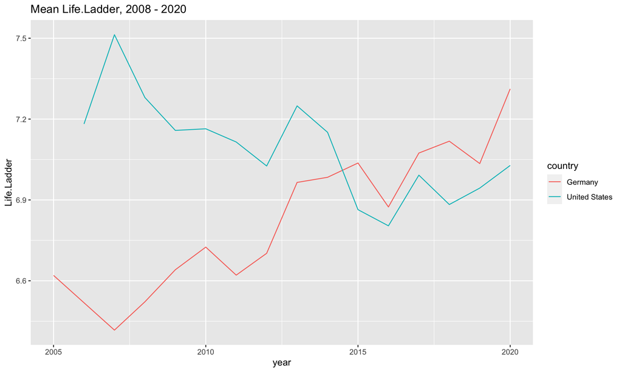

```r
# By using dplyr, we can easily select the rows and columns in the dataframe that we want
# Then we save it to a new dataframe called "whr_data_us_germany"
whr_data_us_germany <- whr_data %>%
  select(country, year, Life.Ladder) %>% #select the interested columns
  filter(country == 'United States' | country == 'Germany')  # choose US AND Germany

# Plot, using "country" as the color aesthetic
ggplot(whr_data_us_germany) + aes(x=year, y=Life.Ladder, color=country) + geom_line() +
  ggtitle("Mean Life.Ladder, 2008 - 2020")
```

### Your turn:

For question 1, you’ll look at the ``Freedom.to.make.life.choices’’ variable but for two DIFFERENT countries (NOT the ones above)

**Q1: (15 pts)** Similar to the analysis above, choose two new countries you’re interested in and make a line plot comparing their ``Freedom.to.make.life.choices’’ variable over time

Hint: To see what countries are options, click on the ``whr_data’’ object in the Environment pane (top right) Notice that not all countries have all years, so pick two countries that have data for the whole time period

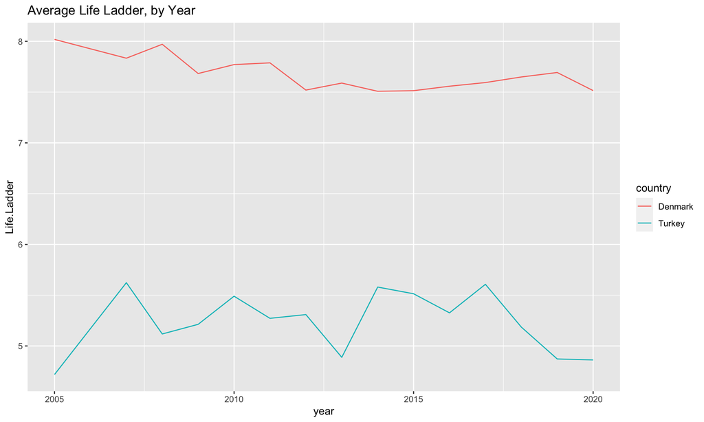

```r
# First, use select() and filter() to create a new dataframe that has only the
# countries and columns you're interested in
whr_data_life_freedom <- whr_data %>%
  select(country, year, Life.Ladder) %>%
  filter(country == 'Turkey' | country == 'Denmark')

# Then, plot!
ggplot(whr_data_life_freedom) + aes(x=year, y=Life.Ladder, color=country) + geom_line() + ggtitle("Average Life Ladder, by Year")
```

# Calculating Correlation

Does a countries measure for “Freedom.to.make.life.choices” correlate with that countries measure for “Life.Ladder”?

Let’s find out. We calculate the correlation, and then we make the scatter plot.

```r
cor(whr_data$Freedom.to.make.life.choices, whr_data$Life.Ladder)
```

```
## [1] NA
```

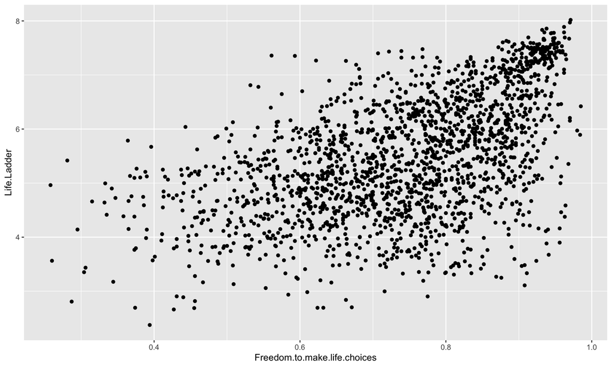

```r
ggplot(whr_data) + aes(x=Freedom.to.make.life.choices, y=Life.Ladder) + geom_point()
```

What happened here? We can see some dots, but the correlation was NA (meaning missing values or undefined). This occurred because there are some missing data points in the data. We can remove all the rows with missing data first, then do the correlation.

We will do this a couple steps, first creating our own dataframe with only the numbers we want to analyze. Similar with the previous case, we can select the columns we want to keep using `select()`. Then we use `filter()` to remove the rows with NAs (! means NOT, so !is.na() means NOT NA)

```r
# Remove NA rows and save it as a new dataframe
whr_clean <- whr_data %>%
               filter(!is.na(Freedom.to.make.life.choices), # ! means NOT, so !is.na() means NOT NA
                      !is.na(Life.Ladder),
                      !is.na(Social.support),
                      !is.na(Positive.affect),
                      !is.na(Negative.affect))

whr_clean_Freedom_LifeLadder <- whr_clean %>%
  select(country, Freedom.to.make.life.choices, Life.Ladder)

# Calculate correlation!
cor(whr_clean_Freedom_LifeLadder$Freedom.to.make.life.choices,
    whr_clean_Freedom_LifeLadder$Life.Ladder)
```

```
## [1] 0.5283698
```

Now we see the correlation is .528. That’s a pretty strong positive correlation!

## Adding line of best fit

Although the scatter plot shows the dots are everywhere, it generally shows that as Freedom to make life choices increases in a country, that country’s life satisfaction (Life.Ladder) also increase. This is a positive correlation. Let’s do this again and add the best fit line, so the trend is more clear. The function to fit the line or simple regression is `lm()`, and the way to use it is `lm(y~x)` where `y~x` is the `formula` to be fitted, `y` is the response or dependent variable, `x` is the explanatory/independent variable, and `~` sign is a separator. Type `?lm` to see more about how to use this function.

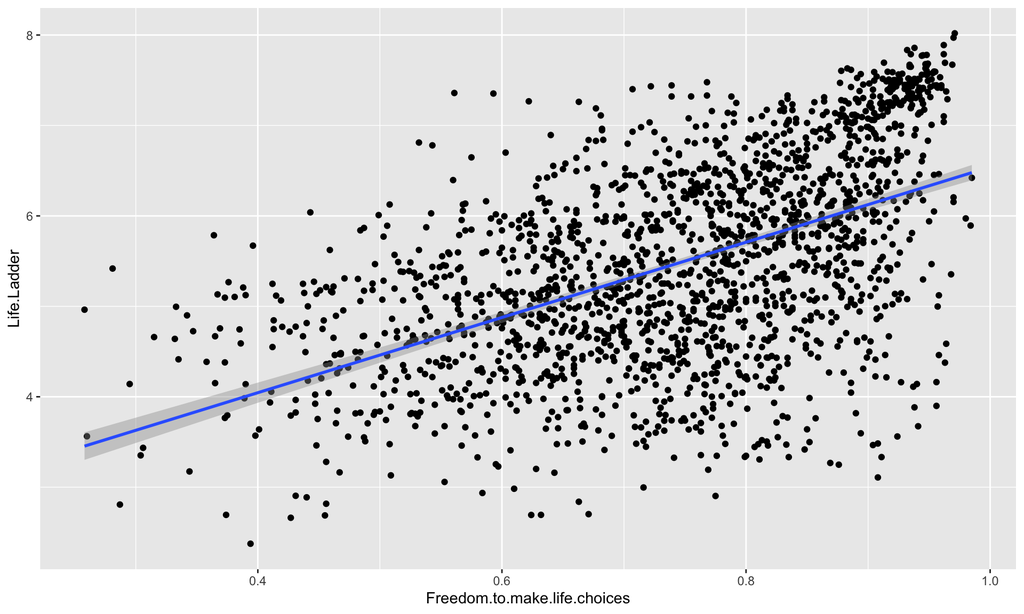

```r
# first make the scatter plot
ggplot(whr_clean_Freedom_LifeLadder) + aes(x=Freedom.to.make.life.choices, y=Life.Ladder) + geom_point() +
  geom_smooth(method='lm', formula=y~x) # Then add the line of best fit! It's as easy as that!
```

# Linear Modeling

In the last code block, we had ggplot fit a linear model and add that line to our plot (with some error margins)

Here, we’ll fit the same linear model and investigate it more

To fit a linear model in R, you use the `lm()` command. Inside the command, you give it a `formula` with the variables you want to model: `lm(y~x)` Notice how the y variable comes FIRST and the x comes SECOND. How you can read this is `target variable ~ predictor variable`

Let’s fit a linear model predicting Life.Ladder (target variable) using Freedom.to.make.life.choices (predictor variable)

```r
linear_model <- lm(whr_data$Life.Ladder~whr_data$Freedom.to.make.life.choices)
```

What `lm(y~x)` does is to fit the simple linear regression model `y = a + bx`. In other words, `lm()` can estimate the coefficients `a` (intercept) and `b` (slope). We can assess the intercept and slope like the following:

```r
# show the summary of the fitted linear model
summary(linear_model)
```

```
##
## Call:
## lm(formula = whr_data$Life.Ladder ~ whr_data$Freedom.to.make.life.choices)
##
## Residuals:
##      Min       1Q   Median       3Q      Max
## -3.04806 -0.64406  0.04139  0.76966  2.64759
##
## Coefficients:
##                                       Estimate Std. Error t value Pr(>|t|)
## (Intercept)                             2.3758     0.1157   20.54   <2e-16 ***
## whr_data$Freedom.to.make.life.choices   4.1633     0.1530   27.21   <2e-16 ***
## ---
## Signif. codes:  0 '***' 0.001 '**' 0.01 '*' 0.05 '.' 0.1 ' ' 1
##
## Residual standard error: 0.9516 on 1915 degrees of freedom
##   (32 observations deleted due to missingness)
## Multiple R-squared:  0.2789, Adjusted R-squared:  0.2785
## F-statistic: 740.5 on 1 and 1915 DF,  p-value: < 2.2e-16
```

```r
# We can access the fitted intercepts and slope values
linear_model$coefficients # this is a vector with two entries, the first one is intercept and other is slope
```

```
##                           (Intercept) whr_data$Freedom.to.make.life.choices
##                              2.375825                              4.163252
```

```r
linear_model$coefficients[1] # is the intercept
```

```
## (Intercept)
##    2.375825
```

```r
linear_model$coefficients[2] # is the slope
```

```
## whr_data$Freedom.to.make.life.choices
##                              4.163252
```

# Your turn: Questions 2-5 ask you to investigate the relationship between two variables.

**Q2: (20 pts)** One of the other columns in the dataset `whr_data`, is `Social.support`. Please calculate the correlation coefficient between Social.support and Life.Ladder. Be careful of the `NA` values in the columns as shown earlier.

Then, interpret what the correlation coefficient means answering these questions:

1. What is the direction of the correlation?
2. How strong is it?
3. Is Social.support more or less correlated to Life.ladder than Freedom.to.make.life.choices is?

**Your answer:**

```r
# select data
whr_clean_Social_Support <- whr_clean %>%
  select(country, Social.support, Life.Ladder)

# assess correlation
cor(whr_clean_Social_Support$Social.support,
    whr_clean_Social_Support$Life.Ladder)
```

```
## [1] 0.7094664
```

#### “Social support” has a stronger positive correlation (.71) to “Life Ladder” than “Freedom to make life choices” does (.53).

Discussion (2-3 sentences):

**Q3: (15 pts)** Following the previous question Q2, please draw a scatter plot between columns `Life.ladder` and `Social.support` (`Social.support` as x axis and `Life.ladder` as y axis) and add the regression line. **Your answer:**

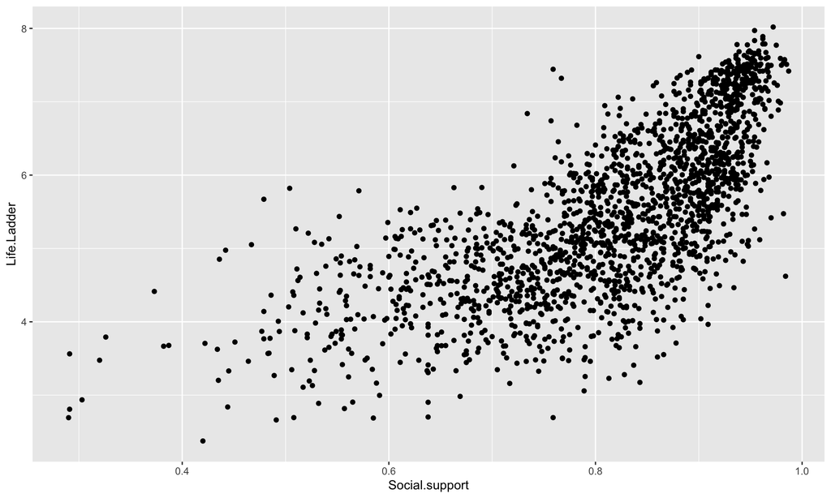

```r
# first make the scatter plot
ggplot(whr_clean) + aes(x=Social.support, y=Life.Ladder) + geom_point()
```

**Q4: (20 pts)** Following the previous question Q3, fit a simple linear regression model to predict `Life.Ladder` using `Social.support` as our predictor. In other words, `Life.ladder` is `y` and `Social.support` is `x`. The regression line can be described as `y = a + bx`. After fitting the model, answer the following questions:

1. What are fitted values for `a` and `b`?
2. Is the value of `b` a positive or negative and what does it mean?
3. Look back to the linear modeling results for `Freedom.to.make.life.choices`. Based on the values of `b` for the two linear models, which variable has a larger impact on Life.Ladder? In other words, per unit increase in Freedom.to.make.life.choices and Social.support, which results in a larger increase in Life.Ladder?

**Your answer:**

```r
# create linear model
social_support_linear_model <- lm(whr_clean_Social_Support$Life.Ladder~whr_clean_Social_Support$Social.support)

summary(social_support_linear_model)
```

```
##
## Call:
## lm(formula = whr_clean_Social_Support$Life.Ladder ~ whr_clean_Social_Support$Social.support)
##
## Residuals:
##     Min      1Q  Median      3Q     Max
## -2.4969 -0.5344  0.0028  0.5951  2.4327
##
## Coefficients:
##                                         Estimate Std. Error t value Pr(>|t|)
## (Intercept)                              0.03717    0.12520   0.297    0.767
## whr_clean_Social_Support$Social.support  6.68294    0.15242  43.847   <2e-16
##
## (Intercept)
## whr_clean_Social_Support$Social.support ***
## ---
## Signif. codes:  0 '***' 0.001 '**' 0.01 '*' 0.05 '.' 0.1 ' ' 1
##
## Residual standard error: 0.7901 on 1897 degrees of freedom
## Multiple R-squared:  0.5033, Adjusted R-squared:  0.5031
## F-statistic:  1923 on 1 and 1897 DF,  p-value: < 2.2e-16
```

```r
# display the linear model coefficients
sprintf("Intercept: %f", social_support_linear_model$coefficients[1])
```

```
## [1] "Intercept: 0.037169"
```

```r
sprintf("Slope: %f", social_support_linear_model$coefficients[2])
```

```
## [1] "Slope: 6.682935"
```

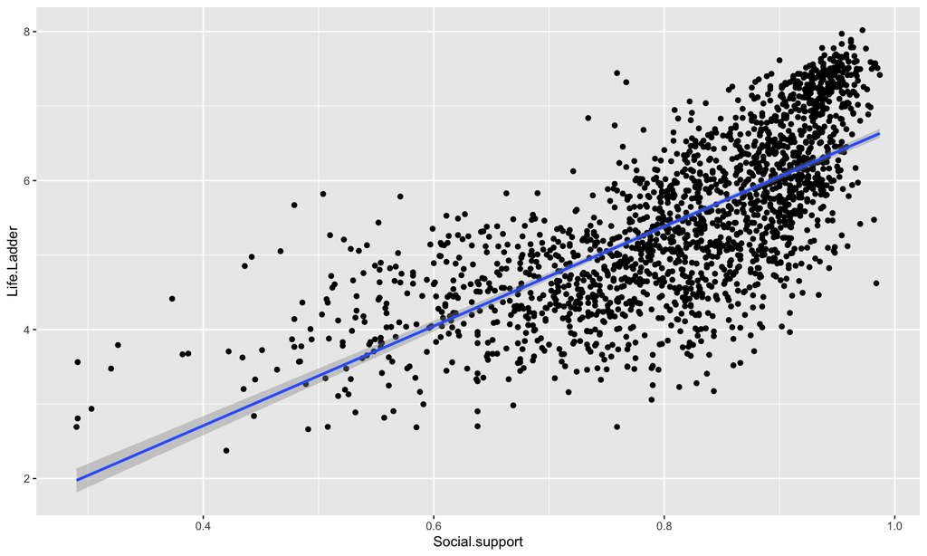

```r
# plot that shit
ggplot(whr_clean) + aes(x=Social.support, y=Life.Ladder) + geom_point() +
  geom_smooth(method='lm', formula=y~x)
```

### Discussion (3-4 sentences):

**Q5: (30 pts)** This question is more open ended and proceeds in multiple steps.

So far, we’ve been focusing on the `Life.Ladder` variable. But there are other other measures of happiness in the dataset, especially `Positive.affect` and `Negative.affect`. Positive affect is the frequency of positive feelings that participants report. Negative affect is the frequency of negative feelings they report. You can google “Positive affect WHR” and “Negative affect WHR” to find out more.

Here’s what you’ll do:

*A* Create a new variable called `Total.affect` using dplyr’s mutate() function

*B* Choose one other variable to analyze in relation to your new variable (can be anything except for Positive and Negative affect)

*C* Create a scatter plot with `Total.affect` on the y-axis and your other variable on the x axis. Add the line of best fit

*D* Calculate Pearson’s correlation coefficient in R

*E* Fit a linear model (remember, put Total.affect first since it’s your y-variable, e.g. lm(whr_data$Total.affect~Other.variable))

*F* In 3-4 sentences, summarize your findings! Is there a relationship between your variable and Total.affect? Is it positive or negative? Is it strong or weak? What do you think this tells us about happiness? Do you think this is a causal relationship or merely correlative?

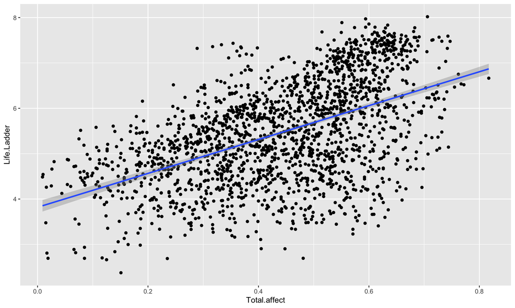

```r
# Part A
whr_clean <- mutate(
  whr_clean, Total.affect = abs(whr_clean$Positive.affect - whr_clean$Negative.affect)
)

# Plot that shit!
ggplot(whr_clean) + aes(x=Total.affect, y=Life.Ladder) + geom_point() + geom_smooth(method='lm', formula=y~x)
```

```r
# Correlation of Total.affect and Life.Ladder
cor(whr_clean$Total.affect, whr_clean$Life.Ladder)
```

```
## [1] 0.5178618
```

```r
# Let's see how Total.affect correlates to Life.ladder!
total_affect_linear_model <- lm(whr_clean$Total.affect~whr_clean$Life.Ladder)

# intercept
total_affect_linear_model$coefficients[1]
```

```
## (Intercept)
##  0.04921543
```

```r
# slope
total_affect_linear_model$coefficients[2]
```

```
## whr_clean$Life.Ladder
##            0.07182479
```

Discussion (3-4 sentences):

Done! Make sure to submit both your .Rmd and knitted .html file to Canvas!